# Precipitação diária estimada pelo modelo Eta

## Introdução

A seguir são descritos os procedimentos para obtenção dos dados de precipitação diária provenientes de previsões realizadas pelo modelo regional Eta, e a conversão desses para o formato matricial (raster) utilizando a linguagem de programação R. As estimativas de precipitação mencionadas foram realizadas em rodadas sub sazonais e disponibilizadas para aplicação em modelagem hidrológica, conforme a demanda do grupo de pesquisa vinculado ao projeto “*Incorporação de previsões climáticas e hidrológicas na gestão da alocação de água do Rio São Francisco*”.

## Estrutura dos dados disponibilizados

As estimativas de precipitação compreenderam o período de 2015 a 2020 e seguiram uma estrutura em grade regular com resolução horizontal de 20 km. As previsões foram incluídas em arquivos compactados `.tar.gz` e disponibilizadas em [servidor FTP](http://ftp1.cptec.inpe.br/pesquisa/grpeta/subsazonal/Gustavo/Eta20km/Benedito/). Cada arquivo compactado correspondente a uma determinada data continha os seguintes arquivos em formato binário `.bin`, e os seus respectivos arquivos descritores `.ctl`:

- `ocis_Eta20km(date).bin`: *downward short wave at ground (W/m²)*;
- `prec_Eta20km(date).bin`: *total precipitation (Kg/m²/day)*;
- `pslc_Eta20km(date).bin`: *surface pressure (hPa)*;
- `tp2m_Eta20km(date).bin`: *2 metre temperature (K)*;
- `u10m_Eta20km(date).bin`: *10 metre u-wind component (m/s)*;
- `umrl_Eta20km(date).bin`: *specific humidity (kg/kg)*;
- `v10m_Eta20km(date).bin`: *10 metre v-wind component (m/s)*;

**Tabela 1** Sequência de previsões de precipitação diária obtidas pelo modelo Eta para os 60 dias consecutivos a partir de uma data inicial di (i = 1, 2, 3, …, 10).

[figure not shown]

## Conversão dos arquivos binários

Foi utilizado o ambiente R para a leitura dos arquivos `.bin` a partir da função `readGradsFile` contida no pacote [readgrads](https://github.com/lhmet/readgrads?ref=https://githubhelp.com), desenvolvido para manipulação de dados provenientes do software [GrADS](http://cola.gmu.edu/grads/) (*Grid Analysis and Display System*).

Após o download do arquivo `.tar.gz` referente a uma determinada data e horário, os arquivos `.bin` e `.ctl` foram descompactados e armazenados em um mesmo diretório. Na sequência, esses foram importados no R e uma função específica foi criada para a sua conversão em imagens raster com extensão `.tiff`. Uma vez que cada arquivo binário continha as sessenta previsões consecutivas, foram criados objetos `RasterStack` contendo uma coleção de sessenta objetos `RasterLayer` com a mesma extensão espacial e resolução (Figura 1). Além disso, a função mencionada também definiu o sistema de referência de coordenadas (SRC) dos arquivos de saída e, neste caso, foi utilizado o datum WGS 84 (*World Geodetic System 1984*), código epsg 4326. Além do pacote `readgrads`, os pacotes `raster`, desenvolvido para operações com dados espaciais em formato matricial e vetorial, e `data.table`, desenvolvido para agregação de grandes conjuntos de dados, foram requeridos para a execução do procedimento mencionado.

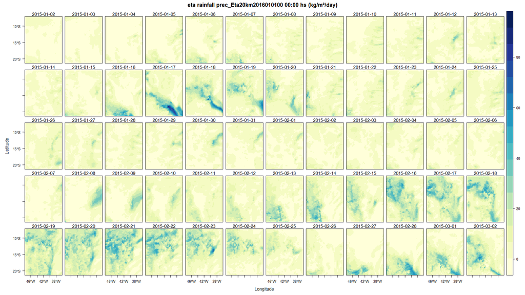

**Figura 1**. Coleção de objetos `RasterLayer` com resolução horizontal de 20 km contidas em um objeto `RasterStack` referente às previsões de precipitação obtidas pelo modelo Eta (00:00 hs) para os 60 dias consecutivos a partir do dia 01/01/2015.

Após a conversão dos arquivos binários em formato raster, foi possível a realização de outras manipulações dos dados e dos arquivos originados, i.e., o recorte e aplicação de uma máscara definida por arquivos em formato vetorial (`shapefile`) contendo o contorno e a discretização de áreas de estudos delimitadas (Figuras 2 e 3). De outra forma, a partir da discretização de uma área definida (Figura 3), foram obtidas estatísticas zonais referentes ao somatório da precipitação diária, calculado conforme os valores dos pixels que sobrepuseram a extensão de cada regionalização (Figura 4).

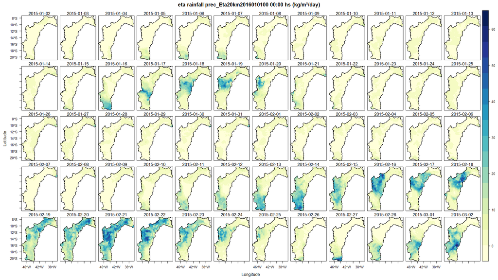

**Figura 2**. Coleção de objetos `RasterLayer` com resolução horizontal de 20 km contidas em um objeto `RasterStack` referente às previsões de precipitação obtidas pelo modelo Eta (00:00 hs) para os 60 dias consecutivos a partir do dia 01/01/2015, recortadas para a extensão da bacia do Rio São Francisco.

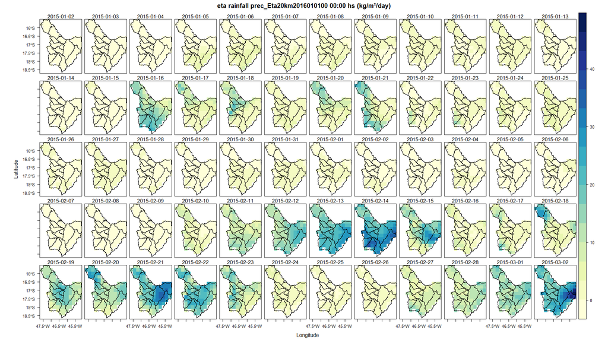

**Figura 3**. Coleção de objetos `RasterLayer` com resolução horizontal de 20 km contidas em um objeto `RasterStack` referente às previsões de precipitação obtidas pelo modelo Eta (00:00 hs) para os 60 dias consecutivos a partir do dia 01/01/2015, recortadas para a extensão da bacia do Rio Paracatu.

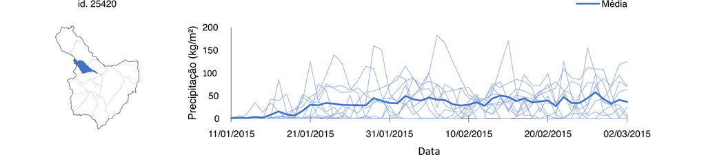

**Figura 4**. Plumas de previsão de precipitação acumulada referente a regionalização id. 25420, estimadas pelo modelo Eta (00:00 hs) a partir do dia 01/01/2015 para o período de 11/01/2015 a 02/03/2015.

## Script

O script a seguir foi desenvolvido para conversão de dados binários `.bin` em dados matriciais `.tiff`. Embora os arquivos `.tar.gz` contenham outras variáveis climáticas, aqui exemplificamos apenas a conversão dos dados de precipitação. Usaremos o arquivo `prec_Eta20km2015010100.bin` (que corresponde as estimativas feitas a partir do dia 01/01/2015, retornadas as 00:00 hs) para entender a estrutura dos dados de previsão. Assim, conforme as informaçõs contidas no arquivo descritor `.ctl`, o arquivo `.bin` apresenta as seguintes componentes:

- `dset`(emsp)^prec_Eta20km2015010100.bin
- `title` File
- `undef` 1e+20
- `xdef` 59 linear -47.8 0.20
- `ydef` 71 linear -21.2 0.20
- `zdef` 1 levels 1000
- `tdef` 241 linear 00Z01Jan2015 6hr
- `vars` 1
- `prec` 1 99 TOTAL PRECIPITATION [Kg/m2/day]
- `endvars`

A componente `tdef` dos arquivos binários apresentou 241 níveis na dimensão do tempo. Uma vez que cada arquivo compreendeu 60 estimativas diárias de precipitação e, desconsiderando o primeiro nível da componente `tdef` (pois todos os seus valores foram iguais a zero), os 240 níveis restantes foram agrupados em intervalos sequenciais a cada 4 níveis. Uma vez que cada nível de `tdef` equivaleu a 6 horas, cada intervalo correspondendeu a 1 dia de estimativa (4 x 6 = 24 horas), resultando em 240/4 = 60 dias de estimativas. Assim, no arquivo `prec_Eta20km2015010100.bin`, por exemplo, as previsões se iniciaram em 02/01/2015 e se extenderam até o dia 02/03/2015.

## Executando o script

### Carregando as bibliotecas requeridas

```r
library(readgrads)
library(data.table)
library(raster)
```

Obs: o pacote `readgrads` pode ser instalado diretamente do github utilizando o seguinte comando (requer o pacote `devtools`)

```r
library(devtools)
devtools::install_github("lhmet/readgrads")
```

### Importando o arquivo binário para o R

Obs: nessa etapa os arquivos `.bin` e `.ctl` devem estar no mesmo diretório e nomeados de forma idêntica. Utilizamos a função `setwd` para indicar o diretório onde os arquivos foram armazenados:

```r
setwd("insira o caminho do arquivo aqui")
```

Em seguida, usamos a função `readGradsFile` do pacote `readgrads` para ler o arquivo `.bin` como um `dataframe` (nesse caso, criamos o objeto `prec` para armazenar o arquivo `prec_Eta20km2015010100.bin`). Adicionalmente, a função `headTail` do pacote `psych`pode ser utilizada para mostrar as primeiras e últimas n linhas do dataframe `prec`.

```r
prec <- readGradsFile(
  'prec_Eta20km2015010100.bin',
  file.ext = ".bin",
  convert2dataframe = TRUE,
  padding.bytes = FALSE
)

library(psych)

headTail(prec)
```

### Escrevendo a função “raster_layers” para conversão do arquivo binário

A função abaixo foi escrita para criar um objeto `RasterStack` contendo uma coleção de arquivos raster em formato `.tiff`, todos com a mesma extensão e resolução espacial:

```r
raster_layers <- function(dat){

  min_tstep <- min(dat$tstep)
  max_tstep <- max(dat$tstep)
  breaks <- seq(min_tstep, max_tstep, by = 4)

  ## Passo 1: criar subconjuntos (dias de previsão) com base na variável tstep do arquivo binário
  dat$group <- cut(dat$tstep, breaks)
  dat <- dat[!is.na(dat$group), ]
  ## Passo 2: calcular os valores de precipitação acumulada
  prec <- setDT(dat)[ , list(prec_sum = sum(prec * 1000)), by = list(group, x, y)]
  ## Passo 3: criar os arquivos raster e incluir o sistema de referência de coordenadas
  layer <- list()
  group <- unique(prec$group)
  j <- 1
  for (i in group){

    raster_dat <- prec[prec$group %in% i , c("x", "y", "prec_sum")]

    colnames(raster_dat)[colnames(raster_dat) == "prec_sum"] <- paste0("prec_sum_", j)
    layer[[j]] <-
      rasterFromXYZ(raster_dat,
                    res = c(0.20, 0.20),
                    crs = sp::CRS("+init=epsg:4326"))
    j <- j + 1
  }
  ## Passo 4: criar o arquivo RasterStack
  stack_prec <- stack(unlist(layer))

  return(stack_prec)
}
```

### Convertendo o arquivo binário

Por fim, a função `raster_layers` foi usada para criar o objeto `raster_stack` contendo os arquivos raster:

```r
raster_stack <- raster_layers(dat = prec)
raster_stack
```